# House Prices - Advanced Regression Techniques5

In this exercise, we’ll try model stacking separately for numeric and factor variables. We’ll also use preprocessing load the required packages first

```r
library(mlr,quietly = TRUE,warn.conflicts = FALSE)
library(dplyr,quietly = TRUE,warn.conflicts = FALSE)
library(ggplot2,quietly = TRUE,warn.conflicts = FALSE)
library(caret,quietly = TRUE,warn.conflicts = FALSE)
library(purrr,quietly = TRUE,warn.conflicts = FALSE)
library(data.table,quietly = TRUE,warn.conflicts = FALSE)
library(readr,quietly = TRUE,warn.conflicts = FALSE)
library(Boruta,warn.conflicts = FALSE)
```

Load the test and train datasets

```r
train=read.csv("train.csv",stringsAsFactors = FALSE)
test=read.csv("test.csv",stringsAsFactors = FALSE)
```

Rbind the two datasets to perform feature engineering, will later separate the two datasets again. Remove the variable Sale Price from the training set

Find the str of the combined train_test dataset. Also take the summary

```r
summary(train_test)
```

```
       Id           MSSubClass       MSZoning          LotFrontage        LotArea          Street
 Min.   :   1.0   Min.   : 20.00   Length:2919        Min.   : 21.00   Min.   :  1300   Length:2919
 1st Qu.: 730.5   1st Qu.: 20.00   Class :character   1st Qu.: 59.00   1st Qu.:  7478   Class :character
 Median :1460.0   Median : 50.00   Mode  :character   Median : 68.00   Median :  9453   Mode  :character
 Mean   :1460.0   Mean   : 57.14                      Mean   : 69.31   Mean   : 10168
 3rd Qu.:2189.5   3rd Qu.: 70.00                      3rd Qu.: 80.00   3rd Qu.: 11570
 Max.   :2919.0   Max.   :190.00                      Max.   :313.00   Max.   :215245
                                                      NA's   :486
    Alley             LotShape         LandContour         Utilities          LotConfig
 Length:2919        Length:2919        Length:2919        Length:2919        Length:2919
 Class :character   Class :character   Class :character   Class :character   Class :character
 Mode  :character   Mode  :character   Mode  :character   Mode  :character   Mode  :character




  LandSlope         Neighborhood        Condition1         Condition2          BldgType
 Length:2919        Length:2919        Length:2919        Length:2919        Length:2919
 Class :character   Class :character   Class :character   Class :character   Class :character
 Mode  :character   Mode  :character   Mode  :character   Mode  :character   Mode  :character




  HouseStyle         OverallQual      OverallCond      YearBuilt     YearRemodAdd   RoofStyle
 Length:2919        Min.   : 1.000   Min.   :1.000   Min.   :1872   Min.   :1950   Length:2919
 Class :character   1st Qu.: 5.000   1st Qu.:5.000   1st Qu.:1954   1st Qu.:1965   Class :character
 Mode  :character   Median : 6.000   Median :5.000   Median :1973   Median :1993   Mode  :character
                    Mean   : 6.089   Mean   :5.565   Mean   :1971   Mean   :1984
                    3rd Qu.: 7.000   3rd Qu.:6.000   3rd Qu.:2001   3rd Qu.:2004
                    Max.   :10.000   Max.   :9.000   Max.   :2010   Max.   :2010

   RoofMatl         Exterior1st        Exterior2nd         MasVnrType          MasVnrArea      ExterQual
 Length:2919        Length:2919        Length:2919        Length:2919        Min.   :   0.0   Length:2919
 Class :character   Class :character   Class :character   Class :character   1st Qu.:   0.0   Class :character
 Mode  :character   Mode  :character   Mode  :character   Mode  :character   Median :   0.0   Mode  :character
                                                                             Mean   : 102.2
                                                                             3rd Qu.: 164.0
                                                                             Max.   :1600.0
                                                                             NA's   :23
```

[output cut: 56 more lines]

```
   X3SsnPorch       ScreenPorch        PoolArea          PoolQC             Fence           MiscFeature
 Min.   :  0.000   Min.   :  0.00   Min.   :  0.000   Length:2919        Length:2919        Length:2919
 1st Qu.:  0.000   1st Qu.:  0.00   1st Qu.:  0.000   Class :character   Class :character   Class :character
 Median :  0.000   Median :  0.00   Median :  0.000   Mode  :character   Mode  :character   Mode  :character
 Mean   :  2.602   Mean   : 16.06   Mean   :  2.252
 3rd Qu.:  0.000   3rd Qu.:  0.00   3rd Qu.:  0.000
 Max.   :508.000   Max.   :576.00   Max.   :800.000

    MiscVal             MoSold           YrSold       SaleType         SaleCondition
 Min.   :    0.00   Min.   : 1.000   Min.   :2006   Length:2919        Length:2919
 1st Qu.:    0.00   1st Qu.: 4.000   1st Qu.:2007   Class :character   Class :character
 Median :    0.00   Median : 6.000   Median :2008   Mode  :character   Mode  :character
 Mean   :   50.83   Mean   : 6.213   Mean   :2008
 3rd Qu.:    0.00   3rd Qu.: 8.000   3rd Qu.:2009
 Max.   :17000.00   Max.   :12.000   Max.   :2010
```

Take all ‘Character’ class types and convert to factor (categorical) types. Add other numeric variables identified above and convert to factor

```r
trn_tst_chr=train_test %>%
  select_if(is.character) %>%
  mutate_each(funs(as.factor))
trn_tst_chr$MSSubClass=as.factor(train_test$MSSubClass)
trn_tst_chr$OverallQual=as.factor(train_test$OverallQual)
trn_tst_chr$OverallCond=as.factor(train_test$OverallCond)
trn_tst_chr$MoSold=as.factor(train_test$MoSold)
str(trn_tst_chr)
```

```
'data.frame':   2919 obs. of  47 variables:
 $ MSZoning     : Factor w/ 5 levels "C (all)","FV",..: 4 4 4 4 4 4 4 4 5 4 ...
 $ Street       : Factor w/ 2 levels "Grvl","Pave": 2 2 2 2 2 2 2 2 2 2 ...
 $ Alley        : Factor w/ 2 levels "Grvl","Pave": NA NA NA NA NA NA NA NA NA NA ...
 $ LotShape     : Factor w/ 4 levels "IR1","IR2","IR3",..: 4 4 1 1 1 1 4 1 4 4 ...
 $ LandContour  : Factor w/ 4 levels "Bnk","HLS","Low",..: 4 4 4 4 4 4 4 4 4 4 ...
 $ Utilities    : Factor w/ 2 levels "AllPub","NoSeWa": 1 1 1 1 1 1 1 1 1 1 ...
 $ LotConfig    : Factor w/ 5 levels "Corner","CulDSac",..: 5 3 5 1 3 5 5 1 5 1 ...
 $ LandSlope    : Factor w/ 3 levels "Gtl","Mod","Sev": 1 1 1 1 1 1 1 1 1 1 ...
 $ Neighborhood : Factor w/ 25 levels "Blmngtn","Blueste",..: 6 25 6 7 14 12 21 17 18 4 ...
 $ Condition1   : Factor w/ 9 levels "Artery","Feedr",..: 3 2 3 3 3 3 3 5 1 1 ...
 $ Condition2   : Factor w/ 8 levels "Artery","Feedr",..: 3 3 3 3 3 3 3 3 3 1 ...
 $ BldgType     : Factor w/ 5 levels "1Fam","2fmCon",..: 1 1 1 1 1 1 1 1 1 2 ...
 $ HouseStyle   : Factor w/ 8 levels "1.5Fin","1.5Unf",..: 6 3 6 6 6 1 3 6 1 2 ...
 $ RoofStyle    : Factor w/ 6 levels "Flat","Gable",..: 2 2 2 2 2 2 2 2 2 2 ...
```

[output cut: 33 more lines]

find the number of NAs in each of the factor variables

```r
colSums(sapply(trn_tst_chr,is.na))
```

```
     MSZoning        Street         Alley      LotShape   LandContour     Utilities     LotConfig     LandSlope
            4             0          2721             0             0             2             0             0
 Neighborhood    Condition1    Condition2      BldgType    HouseStyle     RoofStyle      RoofMatl   Exterior1st
            0             0             0             0             0             0             0             1
  Exterior2nd    MasVnrType     ExterQual     ExterCond    Foundation      BsmtQual      BsmtCond  BsmtExposure
            1            24             0             0             0            81            82            82
 BsmtFinType1  BsmtFinType2       Heating     HeatingQC    CentralAir    Electrical   KitchenQual    Functional
           79            80             0             0             0             1             1             2
  FireplaceQu    GarageType  GarageFinish    GarageQual    GarageCond    PavedDrive        PoolQC         Fence
         1420           157           159           159           159             0          2909          2348
  MiscFeature      SaleType SaleCondition    MSSubClass   OverallQual   OverallCond        MoSold
         2814             1             0             0             0             0             0
```

Variables Alley, FireplaceQu, PoolQC, Fence, MiscFeature have very high NAs and are removed

```r
trn_tst_chr$Alley=NULL
trn_tst_chr$FireplaceQu=NULL
trn_tst_chr$PoolQC=NULL
trn_tst_chr$Fence=NULL
trn_tst_chr$MiscFeature=NULL
# re-run the command for finding total NAs in the factor variables
colSums(sapply(trn_tst_chr,is.na))
```

```
     MSZoning        Street      LotShape   LandContour     Utilities     LotConfig     LandSlope  Neighborhood
            4             0             0             0             2             0             0             0
   Condition1    Condition2      BldgType    HouseStyle     RoofStyle      RoofMatl   Exterior1st   Exterior2nd
            0             0             0             0             0             0             1             1
   MasVnrType     ExterQual     ExterCond    Foundation      BsmtQual      BsmtCond  BsmtExposure  BsmtFinType1
           24             0             0             0            81            82            82            79
 BsmtFinType2       Heating     HeatingQC    CentralAir    Electrical   KitchenQual    Functional    GarageType
           80             0             0             0             1             1             2           157
 GarageFinish    GarageQual    GarageCond    PavedDrive      SaleType SaleCondition    MSSubClass   OverallQual
          159           159           159             0             1             0             0             0
  OverallCond        MoSold
            0             0
```

All variables with Garage that have missing values should be changed to none, likewise all variablesthat have bmst missing values should also be changed to none. Probably these houses don’t have a garage/ basement

```r
#impute the other garage types using the impute function of mlr package
imp_fctr=impute(trn_tst_chr,cols = list(GarageType="none",GarageFinish="none",GarageQual="none",GarageCond="none",
                                      BsmtQual="none",BsmtCond="none",BsmtExposure="none",BsmtFinType1="none",
                                      BsmtFinType2="none"))
imp_fctr$data
```

| MSZoning | Street | LotShape | LandContour | Utilities | LotConfig | LandSlope | Neighborhood | Condition1 | Condition2 | BldgType | HouseStyle | RoofStyle | RoofMatl | Exterior1st | Exterior2nd | MasVnrType | ExterQual | ExterCond | Foundation | BsmtQual | BsmtCond | BsmtExposure | BsmtFinType1 | BsmtFinType2 | Heating | HeatingQC | CentralAir | Electrical | KitchenQual | … |
| --- | --- | --- | --- | --- | --- | --- | --- | --- | --- | --- | --- | --- | --- | --- | --- | --- | --- | --- | --- | --- | --- | --- | --- | --- | --- | --- | --- | --- | --- | --- |
| RL | Pave | Reg | Lvl | AllPub | Inside | Gtl | CollgCr | Norm | Norm | 1Fam | 2Story | Gable | CompShg | VinylSd | VinylSd | BrkFace | Gd | TA | PConc | Gd | TA | No | GLQ | Unf | GasA | Ex | Y | SBrkr | Gd | … |
| RL | Pave | Reg | Lvl | AllPub | FR2 | Gtl | Veenker | Feedr | Norm | 1Fam | 1Story | Gable | CompShg | MetalSd | MetalSd | None | TA | TA | CBlock | Gd | TA | Gd | ALQ | Unf | GasA | Ex | Y | SBrkr | TA | … |
| RL | Pave | IR1 | Lvl | AllPub | Inside | Gtl | CollgCr | Norm | Norm | 1Fam | 2Story | Gable | CompShg | VinylSd | VinylSd | BrkFace | Gd | TA | PConc | Gd | TA | Mn | GLQ | Unf | GasA | Ex | Y | SBrkr | Gd | … |
| RL | Pave | IR1 | Lvl | AllPub | Corner | Gtl | Crawfor | Norm | Norm | 1Fam | 2Story | Gable | CompShg | Wd Sdng | Wd Shng | None | TA | TA | BrkTil | TA | Gd | No | ALQ | Unf | GasA | Gd | Y | SBrkr | Gd | … |
| RL | Pave | IR1 | Lvl | AllPub | FR2 | Gtl | NoRidge | Norm | Norm | 1Fam | 2Story | Gable | CompShg | VinylSd | VinylSd | BrkFace | Gd | TA | PConc | Gd | TA | Av | GLQ | Unf | GasA | Ex | Y | SBrkr | Gd | … |
| RL | Pave | IR1 | Lvl | AllPub | Inside | Gtl | Mitchel | Norm | Norm | 1Fam | 1.5Fin | Gable | CompShg | VinylSd | VinylSd | None | TA | TA | Wood | Gd | TA | No | GLQ | Unf | GasA | Ex | Y | SBrkr | TA | … |
| RL | Pave | Reg | Lvl | AllPub | Inside | Gtl | Somerst | Norm | Norm | 1Fam | 1Story | Gable | CompShg | VinylSd | VinylSd | Stone | Gd | TA | PConc | Ex | TA | Av | GLQ | Unf | GasA | Ex | Y | SBrkr | Gd | … |
| RL | Pave | IR1 | Lvl | AllPub | Corner | Gtl | NWAmes | PosN | Norm | 1Fam | 2Story | Gable | CompShg | HdBoard | HdBoard | Stone | TA | TA | CBlock | Gd | TA | Mn | ALQ | BLQ | GasA | Ex | Y | SBrkr | TA | … |
| RM | Pave | Reg | Lvl | AllPub | Inside | Gtl | OldTown | Artery | Norm | 1Fam | 1.5Fin | Gable | CompShg | BrkFace | Wd Shng | None | TA | TA | BrkTil | TA | TA | No | Unf | Unf | GasA | Gd | Y | FuseF | TA | … |
| RL | Pave | Reg | Lvl | AllPub | Corner | Gtl | BrkSide | Artery | Artery | 2fmCon | 1.5Unf | Gable | CompShg | MetalSd | MetalSd | None | TA | TA | BrkTil | TA | TA | No | GLQ | Unf | GasA | Ex | Y | SBrkr | TA | … |

[output cut: 990 more lines]

```r
colSums(sapply(imp_fctr$data,is.na))
```

```
     MSZoning        Street      LotShape   LandContour     Utilities     LotConfig     LandSlope  Neighborhood
            4             0             0             0             2             0             0             0
   Condition1    Condition2      BldgType    HouseStyle     RoofStyle      RoofMatl   Exterior1st   Exterior2nd
            0             0             0             0             0             0             1             1
   MasVnrType     ExterQual     ExterCond    Foundation      BsmtQual      BsmtCond  BsmtExposure  BsmtFinType1
           24             0             0             0             0             0             0             0
 BsmtFinType2       Heating     HeatingQC    CentralAir    Electrical   KitchenQual    Functional    GarageType
            0             0             0             0             1             1             2             0
 GarageFinish    GarageQual    GarageCond    PavedDrive      SaleType SaleCondition    MSSubClass   OverallQual
            0             0             0             0             1             0             0             0
  OverallCond        MoSold
            0             0
```

```r
trn_tst_chr=imp_fctr$data
#for the remaining variables, we impute using impute mode
imp_fctr=impute(trn_tst_chr,classes = list(factor=imputeMode()))
trn_tst_chr=imp_fctr$data
#check once again for any missing values
colSums(sapply(trn_tst_chr,is.na))
```

```
     MSZoning        Street      LotShape   LandContour     Utilities     LotConfig     LandSlope  Neighborhood
            0             0             0             0             0             0             0             0
   Condition1    Condition2      BldgType    HouseStyle     RoofStyle      RoofMatl   Exterior1st   Exterior2nd
            0             0             0             0             0             0             0             0
   MasVnrType     ExterQual     ExterCond    Foundation      BsmtQual      BsmtCond  BsmtExposure  BsmtFinType1
            0             0             0             0             0             0             0             0
 BsmtFinType2       Heating     HeatingQC    CentralAir    Electrical   KitchenQual    Functional    GarageType
            0             0             0             0             0             0             0             0
 GarageFinish    GarageQual    GarageCond    PavedDrive      SaleType SaleCondition    MSSubClass   OverallQual
            0             0             0             0             0             0             0             0
  OverallCond        MoSold
            0             0
```

```r
#no missing values now
```

Next, Take all numerics variables separately

Find the number of NAs in the numeric variables

```r
colSums(sapply(trn_tst_numeric,is.na))
```

```
           Id   LotFrontage       LotArea    MasVnrArea    BsmtFinSF1    BsmtFinSF2     BsmtUnfSF   TotalBsmtSF
            0           486             0            23             1             1             1             1
    X1stFlrSF     X2ndFlrSF  LowQualFinSF     GrLivArea  BsmtFullBath  BsmtHalfBath      FullBath      HalfBath
            0             0             0             0             2             2             0             0
 BedroomAbvGr  KitchenAbvGr  TotRmsAbvGrd    Fireplaces    GarageCars    GarageArea    WoodDeckSF   OpenPorchSF
            0             0             0             0             1             1             0             0
EnclosedPorch    X3SsnPorch   ScreenPorch      PoolArea       MiscVal      builtage remodelledage     garageage
            0             0             0             0             0             0             0           159
      soldAge
            0
```

```r
colSums(sapply(trn_tst_numeric,is.na))
```

```
           Id   LotFrontage       LotArea    MasVnrArea    BsmtFinSF1    BsmtFinSF2     BsmtUnfSF   TotalBsmtSF
            0             0             0             0             0             0             0             0
    X1stFlrSF     X2ndFlrSF  LowQualFinSF     GrLivArea  BsmtFullBath  BsmtHalfBath      FullBath      HalfBath
            0             0             0             0             0             0             0             0
 BedroomAbvGr  KitchenAbvGr  TotRmsAbvGrd    Fireplaces    GarageCars    GarageArea    WoodDeckSF   OpenPorchSF
            0             0             0             0             0             0             0             0
EnclosedPorch    X3SsnPorch   ScreenPorch      PoolArea       MiscVal      builtage remodelledage     garageage
            0             0             0             0             0             0             0             0
      soldAge
            0
```

Check and remove any constant features (min variation) as they don’t help in machine learning, The percentage of variabilitiy is kept at 5% meaning all features with below 5% variability are removed

```r
trn_tst_numeric=removeConstantFeatures(trn_tst_numeric,perc = 0.05)
```

```
Removing 5 columns: LowQualFinSF,KitchenAbvGr,X3SsnPorch,PoolArea,MiscVal
```

5 variables with low variance were removed. LowQualFinSF,KitchenAbvGr,X3SsnPorch,PoolArea,MiscVal Next visualize intra feature correlation. Load package corrplot

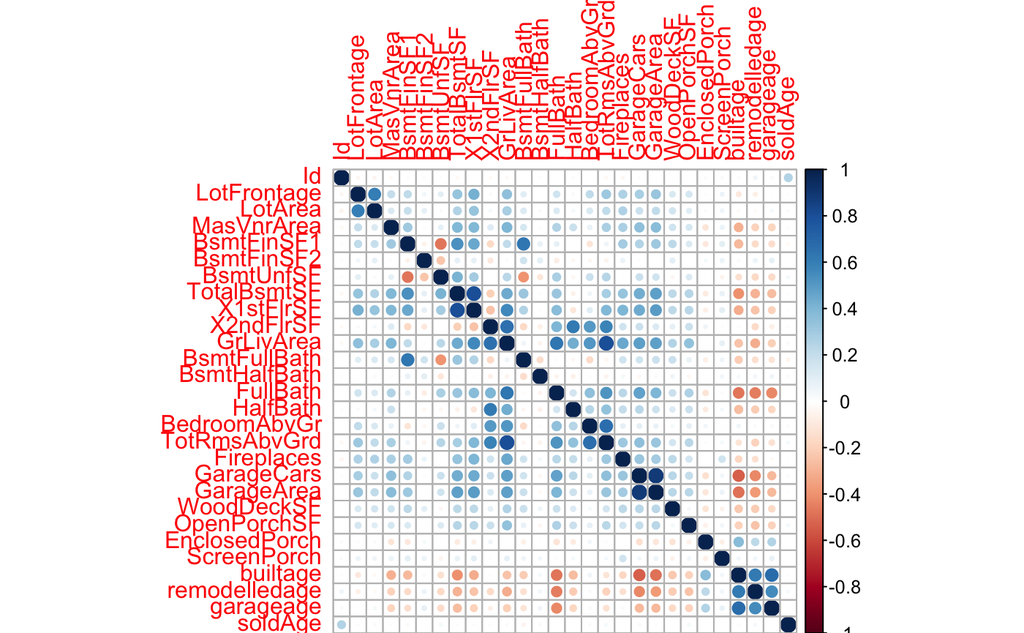

Find variables of high correlation with each other (multicollinearity) and remove them. Use findCorrelation function from Caret package. All variables with more than 70% correlation are flagged and removed

```r
names(trn_tst_numeric[,highcorvar])
```

```
[1] "GrLivArea"  "X1stFlrSF"  "GarageCars"
```

Next, we standardize the numerical vaiables using the normalizeFeatures function of mlr package using method= standardize that centers and scales all numerical variables

combine the two datasets and perform the Boruta function to separate out the feature importance. Before that we separate the data into training and test set

```r
boruta_df=boruta_df %>%
  mutate(borvar=row.names)
```

[output not shown]

select only features that are confirmed or tentative in both training and test models